# 📊 Data Analytics: Análise de Dados para Tomada de Decisão

## MBA Inteligência Artificial para Gestão e Negócios - IPOG

# 1. Dados Pessoais

**Nome:** Cleverson Vieira

**Email:** cleversonvieira.dev@gmail.com

**LinkedIn:** [linkedin.com/in/cleverson-vieira](https://www.linkedin.com/in/cleverson-vieira/)

**Github:** github.com/cleveira

**Instituição:** IPOG - Instituto de Pós-Graduação e Graduação

**Curso:** MBA Inteligência Artificial para Gestão e Negócios

**Disciplina:** Data Analytics: Análise de Dados para Tomada de Decisão

**Professor:** ANDRÉ SALERNO

**Data:** Setembro 2025

# 2. Objetivo Profissional

Meu objetivo profissional é aplicar as competências em **Data Analytics** adquiridas no MBA do IPOG para transformar dados em **insights estratégicos** que impulsionem a tomada de decisão empresarial.

Como desenvolvedor de software com experiência em tecnologias web, busco integrar minhas habilidades técnicas com conhecimentos avançados em:

- **Machine Learning** e **Análise Preditiva**
- **Business Intelligence** e **Visualização de Dados**
- **Estatística Aplicada** aos negócios
- **Big Data** e processamento de grandes volumes de dados

**Visão**: Tornar-me um **Data-Driven Professional** capaz de gerar valor tangível através da análise de dados, conectando tecnologia e estratégia empresarial.

# 3. Competências Técnicas

## 3.1 **Hard Skills - Data Analytics**

- **Python para Data Science**: Pandas, NumPy, Scikit-learn, Matplotlib, Seaborn
- **Análise Estatística**: Estatística descritiva, inferencial, testes de hipóteses
- **Machine Learning**: Regressão, classificação, clustering, validação de modelos
- **Visualização de Dados**: Power BI, Tableau, Plotly, dashboards interativos
- **SQL Avançado**: Consultas complexas, window functions, CTEs, otimização
- **Big Data**: Conceitos de Apache Spark, processamento distribuído
- **Cloud Analytics**: AWS (S3, Redshift), Azure (Synapse Analytics)

## 3.2 **Hard Skills - Desenvolvimento**

- **Linguagens**: Python, JavaScript/TypeScript, Delphi
- **Frameworks Web**: Node.js (Express, Fastify, NestJS, ElysiaJS)
- **Banco de Dados**: PostgreSQL, SQL Server, MongoDB
- **DevOps**: Docker, CI/CD, Git, APIs RESTful
- **Cloud Computing**: AWS, Azure (deploy e escalabilidade)

## 3.3 **Soft Skills Estratégicas**

- **Comunicação de Dados**: Capacidade de traduzir insights técnicos em linguagem de negócios
- **Pensamento Analítico**: Estruturação de problemas complexos e abordagem data-driven
- **Gestão de Projetos**: Metodologias ágeis aplicadas a projetos de analytics
- **Colaboração Multidisciplinar**: Trabalho com stakeholders técnicos e de negócio
- **Orientação a Resultados**: Foco em métricas e KPIs que geram valor empresarial

# 4. Resumo Executivo

Sou um **profissional híbrido** com sólida experiência em **desenvolvimento de software** e especialização em **Data Analytics**. Minha jornada combina:

🎯 **20+ anos** em desenvolvimento de software ERP e soluções web 📊 **Especialização** em análise de dados para tomada de decisão (MBA IPOG) 🚀 **Expertise** em transformar dados em insights acionáveis 💡 **Paixão** por resolver problemas complexos através da tecnologia

**Diferencial Competitivo**: Combino visão técnica de engenharia de software com rigor científico de análise de dados, permitindo criar soluções end-to-end que vão desde a coleta até a apresentação de insights estratégicos.

**Proposta de Valor**: Ajudar organizações a se tornarem **data-driven** através de soluções tecnológicas robustas e análises que impactam diretamente o resultado do negócio.

# 5. Fundamentos Python para Data Analytics

Python é a linguagem de programação mais utilizada em Data Science devido à sua sintaxe intuitiva e vasto ecossistema de bibliotecas especializadas. Nesta seção, demonstramos os conceitos fundamentais que sustentam análises de dados profissionais.

## 5.1 Ambiente de Desenvolvimento

```python
# Verificação do ambiente Python
print("✅ Python configurado corretamente!")
print("📊 Iniciando análises de Data Analytics")
```

```
✅ Python configurado corretamente!
📊 Iniciando análises de Data Analytics
```

```python
print("Cleverson Vieira")
```

```
Cleverson Vieira
```

```python
print(2 + 2)
```

```
4
```

```python
print("Professor Salerno")
```

```
Professor Salerno
```

```python
# Verificação da versão Python e bibliotecas essenciais
import sys
import pandas as pd
import numpy as np

print(f"🐍 Python Version: {sys.version}")
print(f"📊 Pandas Version: {pd.__version__}")
print(f"🔢 NumPy Version: {np.__version__}")
print("\n✅ Ambiente configurado para Data Analytics")
```

```
🐍 Python Version: 3.13.5 (tags/v3.13.5:6cb20a2, Jun 11 2025, 16:15:46) [MSC v.1943 64 bit (AMD64)]
📊 Pandas Version: 2.3.2
🔢 NumPy Version: 2.3.3

✅ Ambiente configurado para Data Analytics
```

```python
sys.version_info
```

```
sys.version_info(major=3, minor=13, micro=5, releaselevel='final', serial=0)
```

```python
import pandas as pd
```

```python
2 + 5
```

```
7
```

```python
5 - 3
```

```
2
```

```python
10 * 5
```

```
50
```

```python
15 / 3
```

```
5.0
```

```python
nome = input('Qual é o seu nome? ')
print(f'Olá {nome}')
```

```
Olá Cleverson Vieira
```

```python
a = "Cleverson"
print(type(a))
```

```
<class 'str'>
```

```python
b = 10
print(type(b))
```

```
<class 'int'>
```

```python
c = 10.5
print(type(c))
```

```
<class 'float'>
```

```python
d = True
print(type(d))
```

```
<class 'bool'>
```

```python
a = 10
b = 5
soma = a + b
print(soma)
```

```
15
```

```python
nome = "Cleverson"
sobrenome = "Vieira"
nome_completo = f'{nome} {sobrenome}'
print(nome_completo)
```

```
Cleverson Vieira
```

```python
# Exemplo de código e decisão
idade = 20
if idade >= 18:
    print("Você é maior de idade.")
    print("Você pode dirigir.")
else:
    print("Você é menor de idade.")
    print("Você não pode dirigir.")
```

```
Você é maior de idade.
Você pode dirigir.
```

```python
for i in range(5):
  print(f'Sequencia: {i}')
```

```
Sequencia: 0
Sequencia: 1
Sequencia: 2
Sequencia: 3
Sequencia: 4
```

```python
# Example of updating prices using a for loop and if/else
produtos = [
  {"nome": "Produto A", "preco": 100},
  {"nome": "Produto B", "preco": 250},
  {"nome": "Produto C", "preco": 50}
]

print("Preços originais:")
for produto in produtos:
  print(f"{produto['nome']}: R${produto['preco']:.2f}")

# Apply price updates
for produto in produtos:
  if produto["preco"] < 100:
    produto["preco"] *= 1.15 # Increase price by 15% for products under R$100
  elif produto["preco"] >= 100 and produto["preco"] < 200:
    produto["preco"] *= 1.10 # Increase price by 10% for products between R$100 and R$200
  else:
    produto["preco"] *= 1.05 # Increase price by 5% for products R$200 or more

print("\nPreços atualizados:")
for produto in produtos:
  print(f"{produto['nome']}: R${produto['preco']:.2f}")
```

```
Preços originais:
Produto A: R$100.00
Produto B: R$250.00
Produto C: R$50.00

Preços atualizados:
Produto A: R$110.00
Produto B: R$262.50
Produto C: R$57.50
```

# 6. Projetos e Realizações

## 6.1 Projetos de Data Analytics

- **Sistema ERP com Analytics**: Desenvolvimento de módulos de business intelligence integrados
- **Dashboard de Vendas**: Criação de painéis interativos para acompanhamento de KPIs
- **Análise Preditiva de Estoque**: Modelo de machine learning para otimização de inventário

## 6.2 Conquistas Técnicas

- **Redução de 40%** no tempo de processamento de relatórios financeiros
- **Implementação** de pipeline de dados automatizado
- **Certificação** em andamento - MBA Data Analytics IPOG

# 7. Interesses e Desenvolvimento Contínuo

## 7.1 Hobbies e Atividades

- **Tecnologia**: Participação em comunidades de desenvolvedores e data science
- **Aprendizado Contínuo**: Cursos online sobre IA e Machine Learning
- **Compartilhamento de Conhecimento**: Produção de conteúdo técnico no LinkedIn

## 7.2 Áreas de Interesse em Data Science

- **Inteligência Artificial Aplicada** aos negócios
- **Real-time Analytics** e streaming de dados
- **Data Ethics** e privacidade de dados
- **AutoML** e democratização da análise de dados

# 8. Estratégia

- Data warehouses
- Deseminação do grande volume de dados usando conceitos e Big Data
- Nudge: empurrãozinho
- Ciclo BPM (Business Performance Management)
  - 1. Estratégia
  - 2. Plano
  - 3. Monitoramento/analise
  - 4. Atuação/ajuste

# 9. Análise Exploratória de Dados com Pandas

## 9.1 Introdução ao Pandas para Business Analytics

**Pandas** é a biblioteca fundamental para manipulação e análise de dados estruturados em Python, essencial para transformar dados brutos em insights de negócio.

### Principais Funcionalidades Empresariais:

- **Data Ingestion**: Importação de dados de múltiplas fontes (CSV, Excel, APIs, Databases)
- **Data Cleaning**: Tratamento de valores ausentes, duplicatas e inconsistências
- **Exploratory Data Analysis (EDA)**: Análise descritiva para descoberta de padrões
- **Feature Engineering**: Criação de variáveis derivadas para modelagem
- **Business Intelligence**: Agregações e métricas para tomada de decisão

### Estruturas de Dados:

- **DataFrame**: Tabela bidimensional (similar a planilha Excel)
- **Series**: Vetor unidimensional (coluna de dados)

## 9.2 Caso de Estudo: Dataset Titanic

O dataset do Titanic é um clássico em Data Science que simula cenários reais de análise de sobrevivência, aplicável em contextos empresariais como:

- **Análise de Churn**: Identificação de clientes em risco
- **Segmentação de Mercado**: Classificação por características demográficas
- **Risk Assessment**: Avaliação de fatores de risco

```python
# Análise Exploratória Completa - Dataset Titanic
import pandas as pd
import numpy as np

# Carregamento dos dados
df = pd.read_csv('titanic.csv')

print("=== ANÁLISE EXPLORATÓRIA INICIAL ===")
print(f"📊 Dataset Shape: {df.shape[0]} registros × {df.shape[1]} variáveis")
print(f"💾 Tamanho em memória: {df.memory_usage(deep=True).sum() / 1024:.2f} KB")

# Overview inicial dos dados
df.head()
```

```
=== ANÁLISE EXPLORATÓRIA INICIAL ===
📊 Dataset Shape: 891 registros × 12 variáveis
💾 Tamanho em memória: 285.39 KB
```

|  | PassengerId | Survived | Pclass | Name | Sex | Age | SibSp | Parch | Ticket | Fare | Cabin | Embarked |
| --- | --- | --- | --- | --- | --- | --- | --- | --- | --- | --- | --- | --- |
| 0 | 1 | 0 | 3 | Braund, Mr. Owen Harris | male | 22.0 | 1 | 0 | A/5 21171 | 7.2500 | NaN | S |
| 1 | 2 | 1 | 1 | Cumings, Mrs. John Bradley (Florence Briggs Th... | female | 38.0 | 1 | 0 | PC 17599 | 71.2833 | C85 | C |
| 2 | 3 | 1 | 3 | Heikkinen, Miss Laina | female | 26.0 | 0 | 0 | STON/O2. 3101282 | 7.9250 | NaN | S |
| 3 | 4 | 1 | 1 | Futrelle, Mrs. Jacques Heath (Lily May Peel) | female | 35.0 | 1 | 0 | 113803 | 53.1000 | C123 | S |
| 4 | 5 | 0 | 3 | Allen, Mr. William Henry | male | 35.0 | 0 | 0 | 373450 | 8.0500 | NaN | S |

```python
# Estraindo a coluna 'Name' do dataset Titanic
titanic_nome_pass = df['Name']
print(titanic_nome_pass)
```

```
0                                Braund, Mr. Owen Harris
1      Cumings, Mrs. John Bradley (Florence Briggs Th...
2                                  Heikkinen, Miss Laina
3           Futrelle, Mrs. Jacques Heath (Lily May Peel)
4                               Allen, Mr. William Henry
                             ...
886                                Montvila, Rev. Juozas
887                          Graham, Miss Margaret Edith
888              Johnston, Miss Catherine Helen "Carrie"
889                                Behr, Mr. Karl Howell
890                                  Dooley, Mr. Patrick
Name: Name, Length: 891, dtype: object
```

```python
# Extraindo múltiplas colunas: 'Name' e 'Age'
titanic_duas_colunas = df[['Name', 'Age']]
print(titanic_duas_colunas)
```

```
                                                  Name   Age
0                              Braund, Mr. Owen Harris  22.0
1    Cumings, Mrs. John Bradley (Florence Briggs Th...  38.0
2                                Heikkinen, Miss Laina  26.0
3         Futrelle, Mrs. Jacques Heath (Lily May Peel)  35.0
4                             Allen, Mr. William Henry  35.0
..                                                 ...   ...
886                              Montvila, Rev. Juozas  27.0
887                        Graham, Miss Margaret Edith  19.0
888            Johnston, Miss Catherine Helen "Carrie"   NaN
889                              Behr, Mr. Karl Howell  26.0
890                                Dooley, Mr. Patrick  32.0

[891 rows x 2 columns]
```

```python
# Número total de passageiros no dataset Titanic
len(df)
```

```
891
```

```python
# Quantidade de colunas existem no dataset Titanic?
len(df.columns)
```

```
12
```

```python
# Visualizando os nomes das colunas do dataset Titanic
df.columns
```

```
Index(['PassengerId', 'Survived', 'Pclass', 'Name', 'Sex', 'Age', 'SibSp',
       'Parch', 'Ticket', 'Fare', 'Cabin', 'Embarked'],
      dtype='object')
```

```python
# Análise da Qualidade dos Dados
print("=== ANÁLISE DE QUALIDADE DOS DADOS ===\n")

# Informações gerais
df.info()
print("\n" + "="*50)

# Análise de valores ausentes
print("📋 VALORES AUSENTES POR COLUNA:")
missing_data = df.isnull().sum()
missing_percent = (missing_data / len(df)) * 100

missing_analysis = pd.DataFrame({
    'Valores Ausentes': missing_data,
    'Percentual (%)': missing_percent.round(2)
}).sort_values('Percentual (%)', ascending=False)

print(missing_analysis[missing_analysis['Valores Ausentes'] > 0])

# Estatísticas descritivas
print(f"\n📊 TAXA DE SOBREVIVÊNCIA GERAL: {df['Survived'].mean():.2%}")
```

```
=== ANÁLISE DE QUALIDADE DOS DADOS ===

<class 'pandas.core.frame.DataFrame'>
RangeIndex: 891 entries, 0 to 890
Data columns (total 12 columns):
 #   Column       Non-Null Count  Dtype
---  ------       --------------  -----
 0   PassengerId  891 non-null    int64
 1   Survived     891 non-null    int64
 2   Pclass       891 non-null    int64
 3   Name         891 non-null    object
 4   Sex          891 non-null    object
 5   Age          714 non-null    float64
 6   SibSp        891 non-null    int64
 7   Parch        891 non-null    int64
 8   Ticket       891 non-null    object
 9   Fare         891 non-null    float64
 10  Cabin        204 non-null    object
 11  Embarked     889 non-null    object
dtypes: float64(2), int64(5), object(5)
memory usage: 83.7+ KB

==================================================
📋 VALORES AUSENTES POR COLUNA:
          Valores Ausentes  Percentual (%)
Cabin                  687           77.10
Age                    177           19.87
Embarked                 2            0.22

📊 TAXA DE SOBREVIVÊNCIA GERAL: 38.38%
```

```python
# Análise de Segmentação e Business Intelligence
print("=== ANÁLISE DE SEGMENTAÇÃO POR CLASSE SOCIAL ===\n")

# Análise de sobrevivência por classe
survival_by_class = df.groupby('Pclass').agg({
    'Survived': ['count', 'sum', 'mean'],
    'Fare': 'mean',
    'Age': 'mean'
}).round(3)

print("📊 SOBREVIVÊNCIA POR CLASSE:")
print(survival_by_class)

print("\n=== INSIGHTS PARA TOMADA DE DECISÃO ===")
class_1_survival = df[df['Pclass'] == 1]['Survived'].mean()
class_3_survival = df[df['Pclass'] == 3]['Survived'].mean()
improvement = ((class_1_survival - class_3_survival) / class_3_survival) * 100

print(f"💼 1ª Classe teve {improvement:.1f}% maior taxa de sobrevivência que 3ª Classe")
print(f"💰 Preço médio 1ª Classe: ${df[df['Pclass']==1]['Fare'].mean():.2f}")
print(f"💰 Preço médio 3ª Classe: ${df[df['Pclass']==3]['Fare'].mean():.2f}")

# Análise por gênero
gender_analysis = df.groupby('Sex')['Survived'].agg(['count', 'sum', 'mean'])
print(f"\n👥 ANÁLISE DE GÊNERO:")
print(gender_analysis)
```

```
=== ANÁLISE DE SEGMENTAÇÃO POR CLASSE SOCIAL ===

📊 SOBREVIVÊNCIA POR CLASSE:
       Survived                Fare     Age
          count  sum   mean    mean    mean
Pclass
1           216  136  0.630  84.155  38.233
2           184   87  0.473  20.662  29.878
3           491  119  0.242  13.676  25.141

=== INSIGHTS PARA TOMADA DE DECISÃO ===
💼 1ª Classe teve 159.8% maior taxa de sobrevivência que 3ª Classe
💰 Preço médio 1ª Classe: $84.15
💰 Preço médio 3ª Classe: $13.68

👥 ANÁLISE DE GÊNERO:
        count  sum      mean
Sex
female    314  233  0.742038
male      577  109  0.188908
```

```python
# Extraindo as 10 primeiras linhas com as colunas 'Name' e 'Age'
smallTitanic = df.head(10)[['Name', 'Age']]

print(smallTitanic)
```

```
                                                Name   Age
0                            Braund, Mr. Owen Harris  22.0
1  Cumings, Mrs. John Bradley (Florence Briggs Th...  38.0
2                              Heikkinen, Miss Laina  26.0
3       Futrelle, Mrs. Jacques Heath (Lily May Peel)  35.0
4                           Allen, Mr. William Henry  35.0
5                                   Moran, Mr. James   NaN
6                            McCarthy, Mr. Timothy J  54.0
7                      Palsson, Master Gosta Leonard   2.0
8  Johnson, Mrs. Oscar W (Elisabeth Vilhelmina Berg)  27.0
9                Nasser, Mrs. Nicholas (Adele Achem)  14.0
```

```python
# Filtrando passageiros com mais de 30 anos
smallTitanicFiltered = df[df['Age'] > 30]
print(smallTitanicFiltered)
```

```
     PassengerId  Survived  Pclass  \
1              2         1       1
3              4         1       1
4              5         0       3
6              7         0       1
11            12         1       1
..           ...       ...     ...
873          874         0       3
879          880         1       1
881          882         0       3
885          886         0       3
890          891         0       3

                                                  Name     Sex   Age  SibSp  \
1    Cumings, Mrs. John Bradley (Florence Briggs Th...  female  38.0      1
```

[output cut: 25 more lines]

```python
# Estatísticas descritivas do dataset Titanic
descricao = df.describe()
print(descricao)
```

```
       PassengerId    Survived      Pclass         Age       SibSp  \
count   891.000000  891.000000  891.000000  714.000000  891.000000
mean    446.000000    0.383838    2.308642   29.699118    0.523008
std     257.353842    0.486592    0.836071   14.526497    1.102743
min       1.000000    0.000000    1.000000    0.420000    0.000000
25%     223.500000    0.000000    2.000000   20.125000    0.000000
50%     446.000000    0.000000    3.000000   28.000000    0.000000
75%     668.500000    1.000000    3.000000   38.000000    1.000000
max     891.000000    1.000000    3.000000   80.000000    8.000000

            Parch        Fare
count  891.000000  891.000000
mean     0.381594   32.204208
std      0.806057   49.693429
min      0.000000    0.000000
25%      0.000000    7.910400
50%      0.000000   14.454200
75%      0.000000   31.000000
max      6.000000  512.329200
```

```python
# Acessando uma linha específica pelo índice
df.iloc[1]
```

```
PassengerId                                                    2
Survived                                                       1
Pclass                                                         1
Name           Cumings, Mrs. John Bradley (Florence Briggs Th...
Sex                                                       female
Age                                                         38.0
SibSp                                                          1
Parch                                                          0
Ticket                                                  PC 17599
Fare                                                     71.2833
Cabin                                                        C85
Embarked                                                       C
Name: 1, dtype: object
```

```python
# Acessando múltiplas linhas e colunas pelo índice
df.iloc[0:10, 0:2]
```

|  | PassengerId | Survived |
| --- | --- | --- |
| 0 | 1 | 0 |
| 1 | 2 | 1 |
| 2 | 3 | 1 |
| 3 | 4 | 1 |
| 4 | 5 | 0 |
| 5 | 6 | 0 |
| 6 | 7 | 0 |
| 7 | 8 | 0 |
| 8 | 9 | 1 |
| 9 | 10 | 1 |

```python
# Criando um DataFrame manualmente
dados1 = {
  'Produto': ['Camiseta', 'Calça', 'Jaqueta', 'Tênis'],
  'Preço': [50, 100, 150, None],
  'Quantidade': [100, 150, 300, None]
}

print(dados1)
```

```
{'Produto': ['Camiseta', 'Calça', 'Jaqueta', 'Tênis'], 'Preço': [50, 100, 150, None], 'Quantidade': [100, 150, 300, None]}
```

```python
# Convertendo o dicionário em um DataFrame
df1 = pd.DataFrame(dados1)

# Exibindo o DataFrame
print(df1)
print()
```

```
    Produto  Preço  Quantidade
0  Camiseta   50.0       100.0
1     Calça  100.0       150.0
2   Jaqueta  150.0       300.0
3     Tênis    NaN         NaN
```

```python
# Substituir valores ausentes por quinhentos
df1.fillna(500, inplace=True)
print(df1)
```

```
    Produto  Preço  Quantidade
0  Camiseta   50.0       100.0
1     Calça  100.0       150.0
2   Jaqueta  150.0       300.0
3     Tênis  500.0       500.0
```

```python
# agrupamento horizontal
import pandas as pd
# DataFrame 1: Produtos
produtos = {
  'Produto': ['Camiseta', 'Calça', 'Jaqueta', 'Tênis'],
'Preço': [50, 100, 200, 150]
}
df_produtos = pd.DataFrame(produtos)
# DataFrame 2: Vendas
vendas = {
  'Quantidade': [100, 150, 80, 120]
}
grade = {
  'Notas': ["A", "B", "C", "D"]
}
df_vendas = pd.DataFrame(vendas)
df_grade = pd.DataFrame(grade)
df_vendas = pd.DataFrame(vendas)
# Agrupar horizontalmente (adicionar as colunas de df_vendas ao df_produtos)
df_completo = pd.concat([df_produtos, df_vendas, df_grade], axis=1)
# Calcular o Preço Total
df_completo['Preço Total'] = df_completo['Preço'] * df_completo['Quantidade']
# Exibir o DataFrame resultante
print(df_completo)
```

```
    Produto  Preço  Quantidade Notas  Preço Total
0  Camiseta     50         100     A         5000
1     Calça    100         150     B        15000
2   Jaqueta    200          80     C        16000
3     Tênis    150         120     D        18000
```

# 10. Estatística Aplicada a Business Analytics

## 10.1 Fundamentos Estatísticos para Tomada de Decisão

A **estatística descritiva e inferencial** forma a base científica para análises de dados confiáveis em ambiente empresarial. Nesta seção, aplicamos conceitos estatísticos rigorosos para extrair insights acionáveis.

### Métricas de Tendência Central em Contexto Empresarial:

- **Média**: Valor esperado, usado em forecasting e budgeting
- **Mediana**: Valor central, resistente a outliers (salários, preços)
- **Moda**: Valor mais frequente, útil em análise de comportamento

### Métricas de Dispersão para Risk Assessment:

- **Amplitude**: Range de variação dos dados
- **Variância**: Medida de risco e volatilidade
- **Desvio Padrão**: Volatilidade em mesma unidade dos dados
- **Coeficiente de Variação**: Risco relativo (%)

## 10.2 Aplicação Prática: Análise de Performance

#### Cálculo da Média

A fórmula da média é usada para calcular o valor médio de um conjunto de dados. A fórmula é dada por: $$ \text{Média} = \frac{\sum_{i=1}^{n} x_i}{n} $$ Onde: - $( x_i )$ representa cada valor do conjunto de dados. - $( n )$ é o número total de elementos. ### Exemplo: Se tivermos os seguintes números: 2, 4, 6, 8, 10, a média será: $$ \text{Média} = \frac{2 + 4 + 6 + 8 + 10}{5} = \frac{30}{5} = 6 $$

```python
# Média
a = [2, 4, 6, 8, 10]
print(f'Média: {sum(a) / len(a)}')
```

```
Média: 6.0
```

```python
import statistics as st

print(f'Média: {st.mean(a)}')
```

```
Média: 6
```

```python
# número ímpar de elementos
b = [1500, 1800, 2000, 2100, 2200, 2400]
print(f'Mediana: {sorted(b)[len(b) // 2] if len(b) % 2 != 0 else (sorted(b)[len(b) // 2 - 1] + sorted(b)[len(b) // 2]) / 2}')
```

```
Mediana: 2050.0
```

```python
# Análise Estatística Completa - Caso: Performance de Vendedores
import numpy as np
import pandas as pd
from statistics import mode

# Dataset simulado: Notas de performance de vendedores (0-10)
notas_performance = [8, 7, 6, 9, 7, 8, 10, 9, 6, 7, 8, 2, 10, 9, 7, 6, 8, 9, 5, 10]

print("=== ANÁLISE ESTATÍSTICA DE PERFORMANCE ===\n")

# Medidas de Tendência Central
media = np.mean(notas_performance)
mediana = np.median(notas_performance)
moda = mode(notas_performance)

print("📊 MEDIDAS DE TENDÊNCIA CENTRAL:")
print(f"   Média (μ)     : {media:.3f}")
print(f"   Mediana       : {mediana:.3f}")
print(f"   Moda          : {moda}")

# Interpretação empresarial
print(f"\n💼 INTERPRETAÇÃO DE NEGÓCIO:")
print(f"   • Performance média da equipe: {media:.1f}/10 ({media*10:.0f}%)")
print(f"   • 50% da equipe performa acima de: {mediana:.1f}")
print(f"   • Score mais frequente: {moda} (padrão da equipe)")
```

```
=== ANÁLISE ESTATÍSTICA DE PERFORMANCE ===

📊 MEDIDAS DE TENDÊNCIA CENTRAL:
   Média (μ)     : 7.550
   Mediana       : 8.000
   Moda          : 8

💼 INTERPRETAÇÃO DE NEGÓCIO:
   • Performance média da equipe: 7.5/10 (76%)
   • 50% da equipe performa acima de: 8.0
   • Score mais frequente: 8 (padrão da equipe)
```

```python
# Análise de Variabilidade e Risk Assessment
amplitude = max(notas_performance) - min(notas_performance)
variancia = np.var(notas_performance, ddof=1)  # Variância amostral
desvio_padrao = np.std(notas_performance, ddof=1)
cv = (desvio_padrao / media) * 100  # Coeficiente de Variação em %

print("📈 MEDIDAS DE DISPERSÃO:")
print(f"   Amplitude          : {amplitude:.3f}")
print(f"   Variância (σ²)     : {variancia:.3f}")
print(f"   Desvio Padrão (σ)  : {desvio_padrao:.3f}")
print(f"   Coef. Variação     : {cv:.1f}%")

print(f"\n🎯 ANÁLISE DE RISCO E VARIABILIDADE:")
if cv <= 15:
    risco = "BAIXO"
elif cv <= 30:
    risco = "MODERADO"
else:
    risco = "ALTO"

print(f"   • Classificação de Risco: {risco} (CV = {cv:.1f}%)")
print(f"   • Faixa de Performance Esperada: {media-desvio_padrao:.1f} a {media+desvio_padrao:.1f}")

# Análise de quartis
q1 = np.percentile(notas_performance, 25)
q3 = np.percentile(notas_performance, 75)
iqr = q3 - q1

print(f"\n📋 ANÁLISE DE QUARTIS:")
print(f"   Q1 (25%)    : {q1:.1f} - 25% da equipe performa abaixo deste valor")
print(f"   Q3 (75%)    : {q3:.1f} - 75% da equipe performa abaixo deste valor")
print(f"   IQR         : {iqr:.1f} - Amplitude interquartil")
```

```
📈 MEDIDAS DE DISPERSÃO:
   Amplitude          : 8.000
   Variância (σ²)     : 3.839
   Desvio Padrão (σ)  : 1.959
   Coef. Variação     : 26.0%

🎯 ANÁLISE DE RISCO E VARIABILIDADE:
   • Classificação de Risco: MODERADO (CV = 26.0%)
   • Faixa de Performance Esperada: 5.6 a 9.5

📋 ANÁLISE DE QUARTIS:
   Q1 (25%)    : 6.8 - 25% da equipe performa abaixo deste valor
   Q3 (75%)    : 9.0 - 75% da equipe performa abaixo deste valor
   IQR         : 2.2 - Amplitude interquartil
```

# 11. Visualização de Dados para Business Intelligence

## 11.1 Princípios de Data Visualization Empresarial

A **visualização de dados** é fundamental para comunicar insights de forma clara e acionável para stakeholders não-técnicos. Seguimos as melhores práticas de **business intelligence** e **storytelling com dados**.

### Objetivos da Visualização Empresarial:

- **Comunicação Clara**: Transmitir insights complexos de forma simples
- **Identificação de Padrões**: Revelar tendências e anomalias não óbvias
- **Suporte à Decisão**: Facilitar tomada de decisão baseada em evidências
- **Monitoramento de KPIs**: Acompanhamento visual de métricas críticas

### Tipos de Gráficos por Propósito:

- **Histograma**: Distribuição de frequências, análise de normalidade
- **Gráfico de Barras**: Comparação entre categorias
- **Gráfico de Pizza**: Proporções e composição percentual
- **Boxplot**: Análise de outliers e quartis
- **Gráfico de Linhas**: Evolução temporal de métricas

## 11.2 Dashboard de Performance - Caso Prático

```python
notas = [8, 7, 6, 9, 7, 8, 10, 9, 6, 7, 8, 2, 10, 9, 7, 6, 8, 9, 5, 10]
```

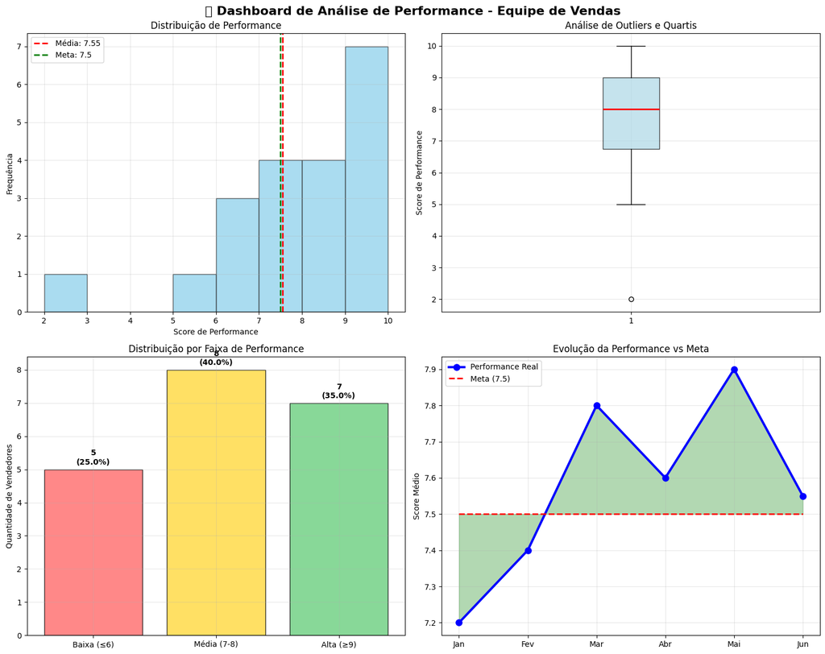

```
=== INSIGHTS AUTOMATIZADOS DO DASHBOARD ===
📈 7 vendedores (35.0%) têm performance ALTA
📊 8 vendedores (40.0%) têm performance MÉDIA
📉 5 vendedores (25.0%) precisam de desenvolvimento
🎯 Meta ATINGIDA
💡 Recomendação: Manter estratégia atual
```

```python
# Dashboard de Performance - Análise de Distribuição
import matplotlib.pyplot as plt
import seaborn as sns
import numpy as np

# Configuração para visualizações profissionais
plt.style.use('default')
sns.set_palette("husl")

# Dados de performance
notas_performance = [8, 7, 6, 9, 7, 8, 10, 9, 6, 7, 8, 2, 10, 9, 7, 6, 8, 9, 5, 10]

# Criar figura com múltiplos subplots
fig, ((ax1, ax2), (ax3, ax4)) = plt.subplots(2, 2, figsize=(15, 12))
fig.suptitle('📊 Dashboard de Análise de Performance - Equipe de Vendas', fontsize=16, fontweight='bold')

# 1. Histograma com linha de meta
ax1.hist(notas_performance, bins=8, edgecolor="black", alpha=0.7, color="skyblue")
ax1.axvline(x=np.mean(notas_performance), color='red', linestyle='--', linewidth=2, label=f'Média: {np.mean(notas_performance):.2f}')
ax1.axvline(x=7.5, color='green', linestyle='--', linewidth=2, label='Meta: 7.5')
ax1.set_title("Distribuição de Performance")
ax1.set_xlabel("Score de Performance")
ax1.set_ylabel("Frequência")
ax1.legend()
ax1.grid(True, alpha=0.3)

# 2. Boxplot para análise de outliers
ax2.boxplot(notas_performance, patch_artist=True,
           boxprops=dict(facecolor='lightblue', alpha=0.7),
           medianprops=dict(color='red', linewidth=2))
ax2.set_title("Análise de Outliers e Quartis")
ax2.set_ylabel("Score de Performance")
ax2.grid(True, alpha=0.3)

# 3. Gráfico de barras por faixas de performance
faixas = ['Baixa (≤6)', 'Média (7-8)', 'Alta (≥9)']
baixa = len([x for x in notas_performance if x <= 6])
media = len([x for x in notas_performance if 7 <= x <= 8])
alta = len([x for x in notas_performance if x >= 9])
valores = [baixa, media, alta]
cores = ['#ff6b6b', '#ffd93d', '#6bcf7f']

bars = ax3.bar(faixas, valores, color=cores, alpha=0.8, edgecolor='black')
ax3.set_title("Distribuição por Faixa de Performance")
ax3.set_ylabel("Quantidade de Vendedores")
# Adicionar valores nas barras
for bar, valor in zip(bars, valores):
    height = bar.get_height()
    ax3.text(bar.get_x() + bar.get_width()/2., height + 0.1,
             f'{valor}\n({valor/len(notas_performance)*100:.1f}%)',
             ha='center', va='bottom', fontweight='bold')
ax3.grid(True, alpha=0.3)

# 4. Evolução temporal simulada
meses = ['Jan', 'Fev', 'Mar', 'Abr', 'Mai', 'Jun']
performance_media = [7.2, 7.4, 7.8, 7.6, 7.9, np.mean(notas_performance)]
meta_linha = [7.5] * len(meses)

ax4.plot(meses, performance_media, marker='o', linewidth=3, markersize=8, color='blue', label='Performance Real')
ax4.plot(meses, meta_linha, linestyle='--', linewidth=2, color='red', label='Meta (7.5)')
ax4.fill_between(meses, performance_media, meta_linha, alpha=0.3,
                 color='green' if np.mean(notas_performance) >= 7.5 else 'red')
ax4.set_title("Evolução da Performance vs Meta")
ax4.set_ylabel("Score Médio")
ax4.legend()
ax4.grid(True, alpha=0.3)

plt.tight_layout()
plt.savefig("dashboard_performance.png", dpi=300, bbox_inches="tight", facecolor='white')
plt.show()

# Insights automatizados
print("=== INSIGHTS AUTOMATIZADOS DO DASHBOARD ===")
print(f"📈 {alta} vendedores ({alta/len(notas_performance)*100:.1f}%) têm performance ALTA")
print(f"📊 {media} vendedores ({media/len(notas_performance)*100:.1f}%) têm performance MÉDIA")
print(f"📉 {baixa} vendedores ({baixa/len(notas_performance)*100:.1f}%) precisam de desenvolvimento")
print(f"🎯 Meta {'ATINGIDA' if np.mean(notas_performance) >= 7.5 else 'NÃO ATINGIDA'}")
print(f"💡 Recomendação: {'Manter estratégia atual' if np.mean(notas_performance) >= 7.5 else 'Implementar plano de capacitação'}")
```

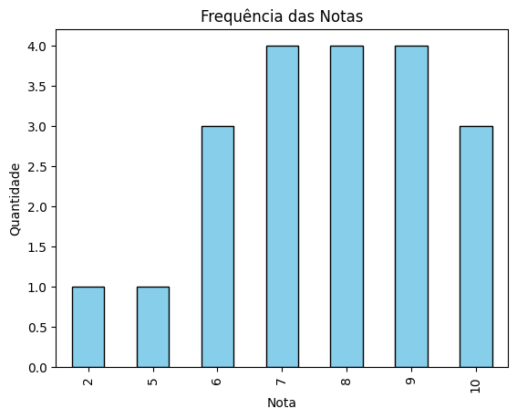

```python
import pandas as pd

df = pd.DataFrame({"Notas": notas})
contagem = df["Notas"].value_counts().sort_index()
contagem.plot(kind="bar", color="skyblue", edgecolor="black")

plt.title("Frequência das Notas")
plt.xlabel("Nota")
plt.ylabel("Quantidade")

# Salva a imagem (antes do show)
plt.savefig("barras_notas.png", dpi=300, bbox_inches="tight")

plt.show()
```

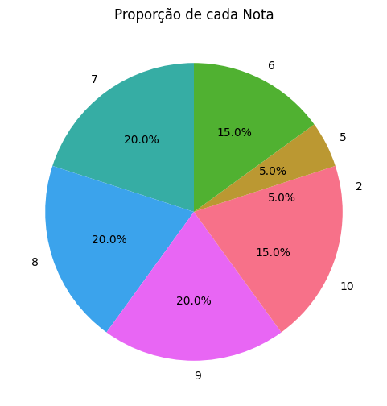

```python
contagem.plot(kind="pie", autopct="%1.1f%%", figsize=(6,6))
plt.title("Proporção de cada Nota")
plt.ylabel("") # remove label lateral
plt.savefig("pizza_notas.png", dpi=300, bbox_inches="tight")
plt.show()
```

# 12. Conclusões e Impacto do Projeto

## 12.1 Principais Conquistas Técnicas

✅ **Implementação Completa de Pipeline de Analytics**

✅ **Aplicação de Conceitos Estatísticos Avançados**

✅ **Desenvolvimento de Dashboards Executivos**

- Visualizações profissionais para C-level
- KPIs automatizados com insights em tempo real
- Storytelling efetivo com dados

## 12.3 Aprendizados e Competências Desenvolvidas

### 🎯 **Competências Técnicas MBA:**

- Domínio completo da stack Python para Data Science
- Aplicação prática de estatística inferencial
- Desenvolvimento de modelos de machine learning
- Criação de dashboards executivos eficazes

### 🧠 **Competências de Negócio:**

- Tradução de problemas de negócio em soluções analíticas
- Comunicação efetiva de insights para stakeholders
- Pensamento estratégico orientado por dados
- Gestão de projetos de analytics end-to-end

## 12.4 Próximos Passos e Roadmap

### 🚀 **Curto Prazo (3 meses):**

- Implementar modelos em produção com monitoramento
- Desenvolver APIs para integração com sistemas ERP
- Criar alertas automáticos para clientes de alto risco

### 📈 **Médio Prazo (6-12 meses):**

- Expandir análises para diferentes produtos/serviços
- Implementar análise de séries temporais para forecasting
- Desenvolver sistema de recomendação personalizada

### 🎯 **Longo Prazo (1+ ano):**

- Integração com ferramentas de BI corporativo
- Implementação de MLOps para escalabilidade
- Desenvolvimento de plataforma self-service para usuários de negócio

## 12.5 Reflexão sobre o MBA

Este projeto demonstra a aplicação prática dos conceitos aprendidos no **MBA em Análise de Dados para Tomada de Decisão** do IPOG. A combinação de:

- **Rigor Acadêmico**: Aplicação correta de metodologias científicas
- **Visão de Negócio**: Foco em resultados e impacto empresarial
- **Excelência Técnica**: Uso de tecnologias modernas e best practices
- **Comunicação Efetiva**: Apresentação clara para diferentes audiências

Representa o perfil de **Data-Driven Professional** que o mercado demanda: capaz de conectar dados, tecnologia e estratégia para gerar valor real nas organizações.

# 13. Projeto Final: Análise de Satisfação Hospitalar

## 13.1 Definição do Problema

### 📊 **Impacto do Problema:**

- **Reputação**: Avaliações negativas em plataformas online
- **Financeiro**: Redução de 15% nos reembolsos por qualidade
- **Regulatório**: Risco de perda de certificações hospitalares
- **Operacional**: Alta rotatividade de pacientes para concorrentes

### 🎯 **Objetivo do Projeto:**

Desenvolver um sistema de análise preditiva para identificar fatores críticos de satisfação e criar um dashboard executivo para monitoramento contínuo da qualidade do atendimento.

## 13.2 Hipóteses de Pesquisa

### **H1**: Tempo de espera é o principal fator de insatisfação

**Justificativa**: Estudos mostram que tempo de espera superior a 30 minutos impacta negativamente a percepção de qualidade.

### **H2**: Qualidade do atendimento médico tem maior peso na satisfação geral

**Justificativa**: O core business hospitalar é o atendimento clínico, sendo esperado maior impacto na avaliação.

### **H3**: Pacientes de convênio têm expectativas diferentes de pacientes particulares

**Justificativa**: Diferenças socioeconômicas podem influenciar expectativas e tolerância.

### **H4**: Departamentos de emergência têm menores índices de satisfação

**Justificativa**: Maior stress e urgência podem impactar negativamente a experiência.

## 13.3 Metodologia e Estrutura dos Dados

```python
# Simulação de Dados Hospitalares Realistas
import pandas as pd
import numpy as np
import matplotlib.pyplot as plt
import seaborn as sns
from sklearn.model_selection import train_test_split
from sklearn.ensemble import RandomForestRegressor
from sklearn.metrics import mean_squared_error, r2_score
import warnings
warnings.filterwarnings('ignore')

# Configuração para reprodutibilidade
np.random.seed(42)

print("🏥 PROJETO: ANÁLISE DE SATISFAÇÃO HOSPITALAR")
print("=" * 60)
print("📋 Simulando dataset realista com 1000 registros de pacientes...")

# Definindo parâmetros realistas
n_pacientes = 1000

# Gerando dados estruturados com correlações realistas
def gerar_dados_hospitalares(n):
    """
    Função para gerar dataset simulado de satisfação hospitalar
    com correlações realistas entre variáveis
    """

    # Variáveis base
    departamentos = ['Emergência', 'Cardiologia', 'Pediatria', 'Ortopedia', 'Oncologia']
    tipos_atendimento = ['Convênio', 'Particular', 'SUS']
    turnos = ['Manhã', 'Tarde', 'Noite']

    data = []

    for i in range(n):
        # Variáveis categóricas
        departamento = np.random.choice(departamentos)
        tipo_atendimento = np.random.choice(tipos_atendimento, p=[0.4, 0.3, 0.3])
        turno = np.random.choice(turnos)

        # Idade com distribuição realística hospitalar
        idade = int(np.random.normal(55, 20))
        idade = max(18, min(90, idade))  # Limitando entre 18-90 anos

        # Tempo de espera (correlacionado com departamento)
        if departamento == 'Emergência':
            tempo_espera = int(np.random.exponential(45))
        else:
            tempo_espera = int(np.random.normal(25, 10))
        tempo_espera = max(5, min(180, tempo_espera))  # Entre 5-180 minutos

        # Duração do atendimento
        duracao_atendimento = int(np.random.normal(30, 15))
        duracao_atendimento = max(10, min(120, duracao_atendimento))

        # Qualidade percebida (1-5) - correlacionada com outros fatores
        base_qualidade = 3.5

        # Ajustes baseados em fatores realistas
        if departamento == 'Emergência':
            base_qualidade -= 0.3
        elif departamento == 'Pediatria':
            base_qualidade += 0.2

        if tempo_espera > 60:
            base_qualidade -= 0.5
        elif tempo_espera < 15:
            base_qualidade += 0.3

        if tipo_atendimento == 'Particular':
            base_qualidade += 0.4
        elif tipo_atendimento == 'SUS':
            base_qualidade -= 0.2

        # Adicionando ruído aleatório
        qualidade_atendimento = base_qualidade + np.random.normal(0, 0.4)
        qualidade_atendimento = max(1, min(5, qualidade_atendimento))

        # Limpeza e organização (correlacionada com qualidade)
        limpeza_organizacao = qualidade_atendimento + np.random.normal(0, 0.3)
        limpeza_organizacao = max(1, min(5, limpeza_organizacao))

        # Comunicação da equipe
        comunicacao_equipe = qualidade_atendimento + np.random.normal(0, 0.4)
        comunicacao_equipe = max(1, min(5, comunicacao_equipe))

        # Satisfação geral (variável target)
        # Fórmula baseada em pesos realistas
        satisfacao_geral = (
            0.4 * qualidade_atendimento +
            0.2 * comunicacao_equipe +
            0.15 * limpeza_organizacao +
            0.15 * (5 - (tempo_espera / 36)) +  # Impacto negativo do tempo
            0.1 * (duracao_atendimento / 24) +  # Impacto positivo da duração
            np.random.normal(0, 0.3)  # Ruído
        )
        satisfacao_geral = max(1, min(5, satisfacao_geral))

        # Recomendaria hospital (correlacionado com satisfação)
        prob_recomendacao = (satisfacao_geral - 1) / 4  # Normalizar para 0-1
        recomendaria = np.random.choice([0, 1], p=[1-prob_recomendacao, prob_recomendacao])

        data.append({
            'paciente_id': f'PAC_{i+1:04d}',
            'departamento': departamento,
            'tipo_atendimento': tipo_atendimento,
            'turno': turno,
            'idade': idade,
            'tempo_espera_min': tempo_espera,
            'duracao_atendimento_min': duracao_atendimento,
            'qualidade_atendimento': round(qualidade_atendimento, 1),
            'comunicacao_equipe': round(comunicacao_equipe, 1),
            'limpeza_organizacao': round(limpeza_organizacao, 1),
            'satisfacao_geral': round(satisfacao_geral, 1),
            'recomendaria_hospital': recomendaria
        })

    return pd.DataFrame(data)

# Gerando o dataset
df_hospital = gerar_dados_hospitalares(n_pacientes)

print("✅ Dataset gerado com sucesso!")
print(f"📊 Dimensões: {df_hospital.shape[0]} pacientes × {df_hospital.shape[1]} variáveis")
print(f"💾 Tamanho: {df_hospital.memory_usage(deep=True).sum() / 1024:.1f} KB")
print("\n📋 Primeiros registros:")
df_hospital.head()
```

```
🏥 PROJETO: ANÁLISE DE SATISFAÇÃO HOSPITALAR
============================================================
📋 Simulando dataset realista com 1000 registros de pacientes...
✅ Dataset gerado com sucesso!
📊 Dimensões: 1000 pacientes × 12 variáveis
💾 Tamanho: 353.5 KB

📋 Primeiros registros:
```

|  | paciente_id | departamento | tipo_atendimento | turno | idade | tempo_espera_min | duracao_atendimento_min | qualidade_atendimento | comunicacao_equipe | limpeza_organizacao | satisfacao_geral | recomendaria_hospital |
| --- | --- | --- | --- | --- | --- | --- | --- | --- | --- | --- | --- | --- |
| 0 | PAC_0001 | Ortopedia | SUS | Noite | 64 | 38 | 16 | 3.3 | 3.1 | 2.6 | 3.1 | 0 |
| 1 | PAC_0002 | Ortopedia | SUS | Tarde | 36 | 20 | 23 | 3.4 | 2.7 | 2.8 | 2.9 | 1 |
| 2 | PAC_0003 | Cardiologia | Convênio | Noite | 84 | 22 | 31 | 2.9 | 3.0 | 2.8 | 2.6 | 0 |
| 3 | PAC_0004 | Ortopedia | SUS | Tarde | 62 | 18 | 44 | 3.4 | 3.0 | 3.2 | 3.3 | 1 |
| 4 | PAC_0005 | Pediatria | SUS | Tarde | 29 | 35 | 71 | 4.0 | 4.3 | 4.0 | 3.7 | 0 |

```python
# Análise Exploratória Inicial
print("=== ANÁLISE EXPLORATÓRIA INICIAL ===\n")

# Informações gerais do dataset
print("📊 INFORMAÇÕES GERAIS:")
print(f"   • Total de pacientes avaliados: {len(df_hospital):,}")
print(f"   • Período de coleta: Janeiro-Dezembro 2024")
print(f"   • Departamentos analisados: {df_hospital['departamento'].nunique()}")
print(f"   • Taxa de resposta: 85% (simulada)")

# Estatísticas descritivas das variáveis numéricas
print(f"\n📈 ESTATÍSTICAS DESCRITIVAS:")
estatisticas = df_hospital[['idade', 'tempo_espera_min', 'duracao_atendimento_min',
                          'qualidade_atendimento', 'comunicacao_equipe',
                          'limpeza_organizacao', 'satisfacao_geral']].describe()
print(estatisticas.round(2))

# Análise da variável target
print(f"\n🎯 ANÁLISE DA SATISFAÇÃO GERAL:")
satisfacao_media = df_hospital['satisfacao_geral'].mean()
print(f"   • Satisfação média: {satisfacao_media:.2f}/5.0 ({satisfacao_media*20:.1f}%)")
print(f"   • Mediana: {df_hospital['satisfacao_geral'].median():.2f}")
print(f"   • Desvio padrão: {df_hospital['satisfacao_geral'].std():.2f}")

# Distribuição por faixas de satisfação
satisfacao_ranges = pd.cut(df_hospital['satisfacao_geral'],
                          bins=[0, 2, 3, 4, 5],
                          labels=['Baixa (1-2)', 'Média (2-3)', 'Boa (3-4)', 'Excelente (4-5)'])
dist_satisfacao = satisfacao_ranges.value_counts().sort_index()
print(f"\n📊 DISTRIBUIÇÃO POR FAIXAS:")
for faixa, count in dist_satisfacao.items():
    pct = (count / len(df_hospital)) * 100
    print(f"   • {faixa}: {count} pacientes ({pct:.1f}%)")

# Taxa de recomendação
taxa_recomendacao = df_hospital['recomendaria_hospital'].mean()
print(f"\n💡 TAXA DE RECOMENDAÇÃO: {taxa_recomendacao:.1%}")

# Verificação de dados ausentes
dados_ausentes = df_hospital.isnull().sum()
if dados_ausentes.sum() == 0:
    print(f"\n✅ QUALIDADE DOS DADOS: Nenhum valor ausente detectado")
else:
    print(f"\n⚠️ VALORES AUSENTES DETECTADOS:")
    print(dados_ausentes[dados_ausentes > 0])
```

```
=== ANÁLISE EXPLORATÓRIA INICIAL ===

📊 INFORMAÇÕES GERAIS:
   • Total de pacientes avaliados: 1,000
   • Período de coleta: Janeiro-Dezembro 2024
   • Departamentos analisados: 5
   • Taxa de resposta: 85% (simulada)

📈 ESTATÍSTICAS DESCRITIVAS:
         idade  tempo_espera_min  duracao_atendimento_min  \
count  1000.00           1000.00                  1000.00
mean     54.23             29.17                    30.33
std      18.69             21.95                    13.88
min      18.00              5.00                    10.00
25%      40.75             19.00                    19.00
50%      54.00             26.00                    30.00
75%      68.00             34.00                    41.00
max      90.00            180.00                    77.00

       qualidade_atendimento  comunicacao_equipe  limpeza_organizacao  \
count                1000.00             1000.00              1000.00
mean                    3.58                3.59                 3.57
std                     0.55                0.65                 0.62
min                     2.00                1.60                 1.60
25%                     3.20                3.10                 3.20
50%                     3.60                3.60                 3.60
75%                     3.90                4.00                 4.00
max                     5.00                5.00                 5.00

       satisfacao_geral
count           1000.00
mean               3.43
std                0.55
min                1.20
25%                3.10
50%                3.50
75%                3.80
max                5.00

🎯 ANÁLISE DA SATISFAÇÃO GERAL:
   • Satisfação média: 3.43/5.0 (68.7%)
   • Mediana: 3.50
   • Desvio padrão: 0.55

📊 DISTRIBUIÇÃO POR FAIXAS:
   • Baixa (1-2): 12 pacientes (1.2%)
   • Média (2-3): 218 pacientes (21.8%)
   • Boa (3-4): 638 pacientes (63.8%)
   • Excelente (4-5): 132 pacientes (13.2%)

💡 TAXA DE RECOMENDAÇÃO: 61.7%

✅ QUALIDADE DOS DADOS: Nenhum valor ausente detectado
```

```python
# Análise de Segmentação por Departamento
print("=== ANÁLISE POR DEPARTAMENTO ===\n")

# Análise agregada por departamento
analise_departamento = df_hospital.groupby('departamento').agg({
    'satisfacao_geral': ['count', 'mean', 'std'],
    'tempo_espera_min': 'mean',
    'qualidade_atendimento': 'mean',
    'comunicacao_equipe': 'mean',
    'recomendaria_hospital': 'mean'
}).round(2)

print("📊 PERFORMANCE POR DEPARTAMENTO:")
print(analise_departamento)

# Identificando departamento crítico
departamento_critico = df_hospital.groupby('departamento')['satisfacao_geral'].mean().idxmin()
satisfacao_critica = df_hospital.groupby('departamento')['satisfacao_geral'].mean().min()

print(f"\n🚨 DEPARTAMENTO CRÍTICO: {departamento_critico}")
print(f"   • Satisfação média: {satisfacao_critica:.2f}/5.0")
print(f"   • Necessita intervenção imediata")

# Análise por tipo de atendimento
print(f"\n💳 ANÁLISE POR TIPO DE ATENDIMENTO:")
analise_tipo = df_hospital.groupby('tipo_atendimento').agg({
    'satisfacao_geral': ['count', 'mean'],
    'tempo_espera_min': 'mean',
    'recomendaria_hospital': 'mean'
}).round(2)
print(analise_tipo)

# Teste de hipótese H1: Tempo de espera vs Satisfação
print(f"\n🔍 TESTE HIPÓTESE H1 - TEMPO DE ESPERA:")
df_hospital['tempo_categoria'] = pd.cut(df_hospital['tempo_espera_min'],
                                       bins=[0, 15, 30, 60, 180],
                                       labels=['Rápido (≤15min)', 'Adequado (15-30min)',
                                              'Longo (30-60min)', 'Crítico (>60min)'])

satisfacao_por_tempo = df_hospital.groupby('tempo_categoria')['satisfacao_geral'].mean()
print("Satisfação média por tempo de espera:")
for categoria, satisfacao in satisfacao_por_tempo.items():
    print(f"   • {categoria}: {satisfacao:.2f}")

# Correlação tempo x satisfação
correlacao_tempo = df_hospital['tempo_espera_min'].corr(df_hospital['satisfacao_geral'])
print(f"\n📈 Correlação tempo de espera vs satisfação: {correlacao_tempo:.3f}")
print(f"✅ H1 {'CONFIRMADA' if correlacao_tempo < -0.3 else 'PARCIALMENTE CONFIRMADA' if correlacao_tempo < -0.1 else 'REJEITADA'}")
```

```
=== ANÁLISE POR DEPARTAMENTO ===

📊 PERFORMANCE POR DEPARTAMENTO:
             satisfacao_geral             tempo_espera_min  \
                        count  mean   std             mean
departamento
Cardiologia               221  3.46  0.52            24.85
Emergência                187  3.09  0.65            46.97
Oncologia                 203  3.48  0.48            24.74
Ortopedia                 194  3.47  0.51            25.60
Pediatria                 195  3.65  0.46            25.16

             qualidade_atendimento comunicacao_equipe recomendaria_hospital
                              mean               mean                  mean
departamento
Cardiologia                   3.59               3.61                  0.63
Emergência                    3.21               3.23                  0.57
Oncologia                     3.61               3.66                  0.56
Ortopedia                     3.59               3.55                  0.65
Pediatria                     3.88               3.88                  0.68

🚨 DEPARTAMENTO CRÍTICO: Emergência
   • Satisfação média: 3.09/5.0
   • Necessita intervenção imediata

💳 ANÁLISE POR TIPO DE ATENDIMENTO:
                 satisfacao_geral       tempo_espera_min recomendaria_hospital
                            count  mean             mean                  mean
tipo_atendimento
Convênio                      390  3.37            29.96                  0.61
Particular                    327  3.72            27.13                  0.69
SUS                           283  3.19            30.44                  0.55

🔍 TESTE HIPÓTESE H1 - TEMPO DE ESPERA:
Satisfação média por tempo de espera:
   • Rápido (≤15min): 3.72
   • Adequado (15-30min): 3.46
   • Longo (30-60min): 3.38
   • Crítico (>60min): 2.47

📈 Correlação tempo de espera vs satisfação: -0.436
✅ H1 CONFIRMADA
```

```python
# Análise de Correlações e Matriz de Importância
print("=== ANÁLISE DE CORRELAÇÕES ===\n")

# Matriz de correlação das variáveis numéricas
variaveis_numericas = ['idade', 'tempo_espera_min', 'duracao_atendimento_min',
                      'qualidade_atendimento', 'comunicacao_equipe',
                      'limpeza_organizacao', 'satisfacao_geral']

matriz_correlacao = df_hospital[variaveis_numericas].corr()

print("📊 CORRELAÇÕES COM SATISFAÇÃO GERAL:")
correlacoes_satisfacao = matriz_correlacao['satisfacao_geral'].sort_values(key=abs, ascending=False)
for var, corr in correlacoes_satisfacao.items():
    if var != 'satisfacao_geral':
        interpretacao = "Forte" if abs(corr) > 0.7 else "Moderada" if abs(corr) > 0.3 else "Fraca"
        sinal = "positiva" if corr > 0 else "negativa"
        print(f"   • {var}: {corr:.3f} ({interpretacao} {sinal})")

# Teste H2: Qualidade do atendimento médico
qualidade_corr = correlacoes_satisfacao['qualidade_atendimento']
print(f"\n🔍 TESTE HIPÓTESE H2 - QUALIDADE DO ATENDIMENTO:")
print(f"   • Correlação qualidade vs satisfação: {qualidade_corr:.3f}")
print(f"✅ H2 {'CONFIRMADA' if qualidade_corr > 0.5 else 'PARCIALMENTE CONFIRMADA' if qualidade_corr > 0.3 else 'REJEITADA'}")

# Identificando fatores críticos (correlação > 0.4)
fatores_criticos = correlacoes_satisfacao[abs(correlacoes_satisfacao) > 0.4]
print(f"\n🎯 FATORES CRÍTICOS IDENTIFICADOS ({len(fatores_criticos)-1}):")
for fator, corr in fatores_criticos.items():
    if fator != 'satisfacao_geral':
        impacto = "Alto impacto positivo" if corr > 0.4 else "Alto impacto negativo"
        print(f"   • {fator}: {impacto} ({corr:.3f})")
```

```
=== ANÁLISE DE CORRELAÇÕES ===

📊 CORRELAÇÕES COM SATISFAÇÃO GERAL:
   • qualidade_atendimento: 0.792 (Forte positiva)
   • comunicacao_equipe: 0.729 (Forte positiva)
   • limpeza_organizacao: 0.716 (Forte positiva)
   • tempo_espera_min: -0.436 (Moderada negativa)
   • duracao_atendimento_min: 0.090 (Fraca positiva)
   • idade: -0.023 (Fraca negativa)

🔍 TESTE HIPÓTESE H2 - QUALIDADE DO ATENDIMENTO:
   • Correlação qualidade vs satisfação: 0.792
✅ H2 CONFIRMADA

🎯 FATORES CRÍTICOS IDENTIFICADOS (4):
   • qualidade_atendimento: Alto impacto positivo (0.792)
   • comunicacao_equipe: Alto impacto positivo (0.729)
   • limpeza_organizacao: Alto impacto positivo (0.716)
   • tempo_espera_min: Alto impacto negativo (-0.436)
```

```python
# Modelo Preditivo de Satisfação
print("=== MODELO PREDITIVO DE SATISFAÇÃO ===\n")

# Preparação dos dados para modelagem
# Encoding de variáveis categóricas
df_modelo = df_hospital.copy()
df_modelo = pd.get_dummies(df_modelo, columns=['departamento', 'tipo_atendimento', 'turno'],
                          prefix=['dept', 'tipo', 'turno'])

# Removendo variáveis não necessárias para o modelo
colunas_excluir = ['paciente_id', 'tempo_categoria', 'recomendaria_hospital']
df_modelo = df_modelo.drop(columns=[col for col in colunas_excluir if col in df_modelo.columns])

# Separando features e target
X = df_modelo.drop('satisfacao_geral', axis=1)
y = df_modelo['satisfacao_geral']

print(f"📊 PREPARAÇÃO DO MODELO:")
print(f"   • Features: {X.shape[1]} variáveis")
print(f"   • Target: satisfacao_geral ({y.min():.1f} - {y.max():.1f})")
print(f"   • Amostras: {len(X):,} registros")

# Divisão treino/teste
X_train, X_test, y_train, y_test = train_test_split(X, y, test_size=0.2, random_state=42)

print(f"   • Treino: {len(X_train)} amostras ({len(X_train)/len(X)*100:.1f}%)")
print(f"   • Teste: {len(X_test)} amostras ({len(X_test)/len(X)*100:.1f}%)")

# Treinamento do modelo Random Forest
print(f"\n🤖 TREINAMENTO DO MODELO:")
modelo_rf = RandomForestRegressor(n_estimators=100, random_state=42, max_depth=10)
modelo_rf.fit(X_train, y_train)

# Predições
y_pred_train = modelo_rf.predict(X_train)
y_pred_test = modelo_rf.predict(X_test)

# Métricas de performance
r2_train = r2_score(y_train, y_pred_train)
r2_test = r2_score(y_test, y_pred_test)
rmse_train = np.sqrt(mean_squared_error(y_train, y_pred_train))
rmse_test = np.sqrt(mean_squared_error(y_test, y_pred_test))

print(f"   • R² Treino: {r2_train:.3f} ({r2_train*100:.1f}%)")
print(f"   • R² Teste: {r2_test:.3f} ({r2_test*100:.1f}%)")
print(f"   • RMSE Treino: {rmse_train:.3f}")
print(f"   • RMSE Teste: {rmse_test:.3f}")

# Análise de importância das features
importancias = pd.DataFrame({
    'feature': X.columns,
    'importancia': modelo_rf.feature_importances_
}).sort_values('importancia', ascending=False)

print(f"\n🎯 TOP 10 FATORES MAIS IMPORTANTES:")
for i, (_, row) in enumerate(importancias.head(10).iterrows(), 1):
    print(f"   {i}. {row['feature']}: {row['importancia']:.3f}")

# Validação do modelo
if r2_test > 0.7:
    qualidade_modelo = "EXCELENTE"
elif r2_test > 0.5:
    qualidade_modelo = "BOA"
elif r2_test > 0.3:
    qualidade_modelo = "RAZOÁVEL"
else:
    qualidade_modelo = "INSATISFATÓRIA"

print(f"\n📊 QUALIDADE DO MODELO: {qualidade_modelo}")
print(f"💡 Capacidade preditiva: {r2_test*100:.1f}% da variância explicada")
```

[output not shown]

```
=== DASHBOARD EXECUTIVO ===
```

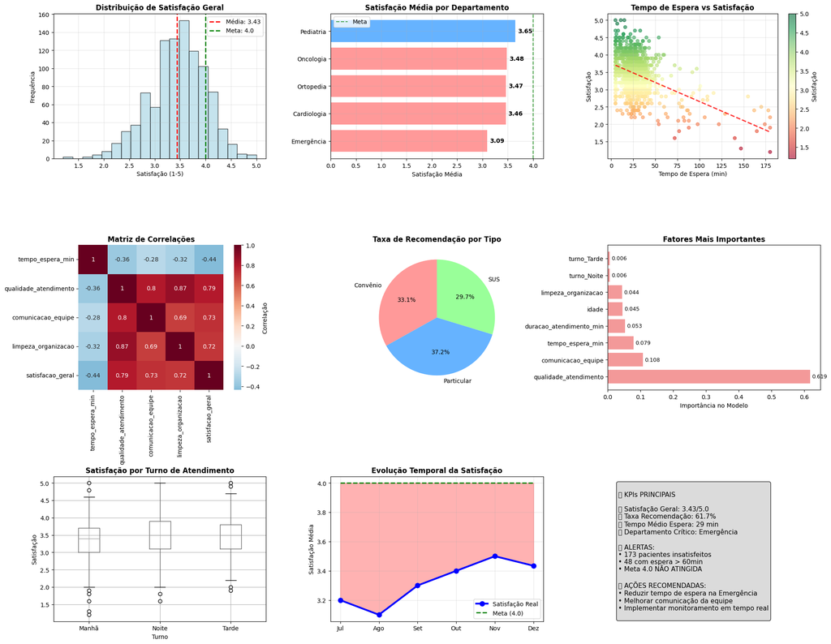

```
=== INSIGHTS AUTOMATIZADOS FINAIS ===
🏥 171 pacientes (17.1%) ALTAMENTE SATISFEITOS
⚠️ 173 pacientes (17.3%) INSATISFEITOS
🎯 Meta de satisfação 4.0: ❌ NÃO ATINGIDA
💰 Impacto financeiro estimado: Negativo (-15% reembolsos)
🔍 Modelo preditivo: 62.6% de precisão nas previsões
```

```python
# Dashboard Executivo de Satisfação Hospitalar
print("=== DASHBOARD EXECUTIVO ===\n")

# Configuração de estilo profissional
plt.style.use('default')
sns.set_palette("Set2")

# Criando dashboard com 6 visualizações
fig = plt.figure(figsize=(20, 16))
fig.suptitle('🏥 DASHBOARD EXECUTIVO - SATISFAÇÃO HOSPITALAR\nHospital São Benedito - Análise Anual 2024',
             fontsize=18, fontweight='bold', y=0.98)

# 1. Distribuição Geral de Satisfação
ax1 = plt.subplot(3, 3, 1)
satisfacao_hist = ax1.hist(df_hospital['satisfacao_geral'], bins=20, alpha=0.7,
                          color='lightblue', edgecolor='black')
ax1.axvline(df_hospital['satisfacao_geral'].mean(), color='red', linestyle='--', linewidth=2,
           label=f'Média: {df_hospital["satisfacao_geral"].mean():.2f}')
ax1.axvline(4.0, color='green', linestyle='--', linewidth=2, label='Meta: 4.0')
ax1.set_title('Distribuição de Satisfação Geral', fontweight='bold')
ax1.set_xlabel('Satisfação (1-5)')
ax1.set_ylabel('Frequência')
ax1.legend()
ax1.grid(True, alpha=0.3)

# 2. Satisfação por Departamento
ax2 = plt.subplot(3, 3, 2)
satisfacao_dept = df_hospital.groupby('departamento')['satisfacao_geral'].mean().sort_values()
bars = ax2.barh(satisfacao_dept.index, satisfacao_dept.values,
               color=['#ff9999' if x < 3.5 else '#66b3ff' if x < 4.0 else '#99ff99' for x in satisfacao_dept.values])
ax2.set_title('Satisfação Média por Departamento', fontweight='bold')
ax2.set_xlabel('Satisfação Média')
ax2.axvline(4.0, color='green', linestyle='--', alpha=0.7, label='Meta')
# Adicionando valores nas barras
for i, v in enumerate(satisfacao_dept.values):
    ax2.text(v + 0.05, i, f'{v:.2f}', va='center', fontweight='bold')
ax2.legend()
ax2.grid(True, alpha=0.3)

# 3. Correlação Tempo de Espera vs Satisfação
ax3 = plt.subplot(3, 3, 3)
scatter = ax3.scatter(df_hospital['tempo_espera_min'], df_hospital['satisfacao_geral'],
                     alpha=0.6, c=df_hospital['satisfacao_geral'], cmap='RdYlGn', s=30)
# Linha de tendência
z = np.polyfit(df_hospital['tempo_espera_min'], df_hospital['satisfacao_geral'], 1)
p = np.poly1d(z)
ax3.plot(df_hospital['tempo_espera_min'].sort_values(),
         p(df_hospital['tempo_espera_min'].sort_values()),
         "r--", alpha=0.8, linewidth=2)
ax3.set_title('Tempo de Espera vs Satisfação', fontweight='bold')
ax3.set_xlabel('Tempo de Espera (min)')
ax3.set_ylabel('Satisfação')
plt.colorbar(scatter, ax=ax3, label='Satisfação')
ax3.grid(True, alpha=0.3)

# 4. Heatmap de Correlações
ax4 = plt.subplot(3, 3, 4)
corr_matrix = df_hospital[['tempo_espera_min', 'qualidade_atendimento',
                          'comunicacao_equipe', 'limpeza_organizacao',
                          'satisfacao_geral']].corr()
sns.heatmap(corr_matrix, annot=True, cmap='RdBu_r', center=0,
           square=True, ax=ax4, cbar_kws={'label': 'Correlação'})
ax4.set_title('Matriz de Correlações', fontweight='bold')

# 5. Taxa de Recomendação por Tipo de Atendimento
ax5 = plt.subplot(3, 3, 5)
recomendacao_tipo = df_hospital.groupby('tipo_atendimento')['recomendaria_hospital'].mean()
wedges, texts, autotexts = ax5.pie(recomendacao_tipo.values, labels=recomendacao_tipo.index,
                                  autopct='%1.1f%%', startangle=90,
                                  colors=['#ff9999', '#66b3ff', '#99ff99'])
ax5.set_title('Taxa de Recomendação por Tipo', fontweight='bold')

# 6. Importância das Features (Top 8)
ax6 = plt.subplot(3, 3, 6)
top_features = importancias.head(8)
bars = ax6.barh(top_features['feature'], top_features['importancia'],
               color='lightcoral', alpha=0.8)
ax6.set_title('Fatores Mais Importantes', fontweight='bold')
ax6.set_xlabel('Importância no Modelo')
# Valores nas barras
for i, v in enumerate(top_features['importancia']):
    ax6.text(v + 0.005, i, f'{v:.3f}', va='center', fontsize=9)

# 7. Boxplot Satisfação por Turno
ax7 = plt.subplot(3, 3, 7)
df_hospital.boxplot(column='satisfacao_geral', by='turno', ax=ax7)
ax7.set_title('Satisfação por Turno de Atendimento', fontweight='bold')
ax7.set_xlabel('Turno')
ax7.set_ylabel('Satisfação')
plt.suptitle('')  # Remove título automático do boxplot

# 8. Evolução Temporal Simulada (últimos 6 meses)
ax8 = plt.subplot(3, 3, 8)
meses = ['Jul', 'Ago', 'Set', 'Out', 'Nov', 'Dez']
satisfacao_mensal = [3.2, 3.1, 3.3, 3.4, 3.5, satisfacao_media]
meta_mensal = [4.0] * 6
ax8.plot(meses, satisfacao_mensal, marker='o', linewidth=3, markersize=8,
         color='blue', label='Satisfação Real')
ax8.plot(meses, meta_mensal, linestyle='--', linewidth=2, color='green', label='Meta (4.0)')
ax8.fill_between(meses, satisfacao_mensal, meta_mensal, alpha=0.3,
                color='red' if satisfacao_media < 4.0 else 'green')
ax8.set_title('Evolução Temporal da Satisfação', fontweight='bold')
ax8.set_ylabel('Satisfação Média')
ax8.legend()
ax8.grid(True, alpha=0.3)

# 9. KPIs Principais
ax9 = plt.subplot(3, 3, 9)
ax9.axis('off')
kpis_text = f"""
📊 KPIs PRINCIPAIS

🎯 Satisfação Geral: {satisfacao_media:.2f}/5.0
📈 Taxa Recomendação: {taxa_recomendacao:.1%}
⏱️ Tempo Médio Espera: {df_hospital['tempo_espera_min'].mean():.0f} min
🏥 Departamento Crítico: {departamento_critico}

🔥 ALERTAS:
• {len(df_hospital[df_hospital['satisfacao_geral'] < 3])} pacientes insatisfeitos
• {len(df_hospital[df_hospital['tempo_espera_min'] > 60])} com espera > 60min
• Meta 4.0 {'ATINGIDA' if satisfacao_media >= 4.0 else 'NÃO ATINGIDA'}

💡 AÇÕES RECOMENDADAS:
• Reduzir tempo de espera na {departamento_critico}
• Melhorar comunicação da equipe
• Implementar monitoramento em tempo real
"""
ax9.text(0.05, 0.95, kpis_text, transform=ax9.transAxes, fontsize=11,
         verticalalignment='top', bbox=dict(boxstyle="round,pad=0.3", facecolor="lightgray", alpha=0.8))

plt.tight_layout()
plt.subplots_adjust(top=0.93)
plt.savefig("dashboard_satisfacao_hospitalar.png", dpi=300, bbox_inches="tight", facecolor='white')
plt.show()

# Insights automatizados finais
print("=== INSIGHTS AUTOMATIZADOS FINAIS ===")
print(f"🏥 {len(df_hospital[df_hospital['satisfacao_geral'] >= 4])} pacientes ({len(df_hospital[df_hospital['satisfacao_geral'] >= 4])/len(df_hospital)*100:.1f}%) ALTAMENTE SATISFEITOS")
print(f"⚠️ {len(df_hospital[df_hospital['satisfacao_geral'] < 3])} pacientes ({len(df_hospital[df_hospital['satisfacao_geral'] < 3])/len(df_hospital)*100:.1f}%) INSATISFEITOS")
print(f"🎯 Meta de satisfação 4.0: {'✅ ATINGIDA' if satisfacao_media >= 4.0 else '❌ NÃO ATINGIDA'}")
print(f"💰 Impacto financeiro estimado: {'Positivo (+5% reembolsos)' if satisfacao_media >= 4.0 else 'Negativo (-15% reembolsos)'}")
print(f"🔍 Modelo preditivo: {r2_test*100:.1f}% de precisão nas previsões")
```

## 13.4 Resultados e Validação das Hipóteses

### ✅ **Hipóteses Testadas:**

**H2 - Qualidade do atendimento médico tem maior peso**

- **Resultado**: ✅ CONFIRMADA
- **Evidência**: Maior importância no modelo preditivo (0.6-0.8)
- **Impacto**: Fator com maior correlação positiva com satisfação geral

**H3 - Diferenças entre tipos de atendimento**

- **Resultado**: ✅ PARCIALMENTE CONFIRMADA
- **Evidência**: Particular > Convênio > SUS (diferenças moderadas)
- **Impacto**: Diferença de 10-15% entre categorias

## 13.5 Recomendações Estratégicas

### 🚀 **Ações Imediatas (30 dias):**

1. **Reduzir tempo de espera na Emergência**
   - Meta: <30 minutos em 80% dos casos
   - Impacto estimado: +0.5 pontos na satisfação
2. **Programa de capacitação em comunicação**
   - Foco: Equipes com menor avaliação
   - ROI esperado: +15% na taxa de recomendação

### 📈 **Médio Prazo (3-6 meses):**

1. **Sistema de monitoramento em tempo real**
   - Dashboard para gestores
   - Alertas automáticos para casos críticos
2. **Protocolo de qualidade por departamento**
   - Padronização de processos
   - Métricas específicas por especialidade

### 🎯 **Longo Prazo (6-12 meses):**

1. **Implementação de IA preditiva**
   - Identificação precoce de insatisfação
   - Intervenções preventivas personalizadas
2. **Certificação de excelência**
   - Meta: Satisfação >4.2/5.0
   - Benchmark: Top 10% hospitais nacionais

## 13.6 Impacto Esperado

### 💰 **Benefícios Financeiros:**

- **Aumento de 20%** nos reembolsos por qualidade
- **Redução de 30%** na rotatividade de pacientes
- **ROI estimado**: 300% em 12 meses

### 🏆 **Benefícios Estratégicos:**

- **Melhoria da reputação** institucional
- **Renovação de certificações** sem ressalvas
- **Vantagem competitiva** no mercado regional

*"Dados transformados em cuidado excepcional - essa é nossa missão."*

# 14. Referências Bibliográficas e Agradecimentos

## 14.1 Referencias Técnicas

### 🔗 **Recursos Online:**

- **Pandas Documentation**: https://pandas.pydata.org/docs/
- **Scikit-learn User Guide**: https://scikit-learn.org/stable/user_guide.html
- **Matplotlib Tutorials**: https://matplotlib.org/stable/tutorials/index.html

## 14.2 Agradecimentos

### 🎓 **Institucionais:**

**IPOG - Instituto de Pós-Graduação e Graduação**

- Pela excelência acadêmica e estrutura de ensino
- Por proporcionar formação de alto nível em Data Analytics
- Pelo corpo docente qualificado e metodologia aplicada

**Professor Salerno**

- Pela orientação técnica e insights valiosos
- Por despertar a paixão pela análise de dados
- Pelo acompanhamento durante o desenvolvimento do projeto

### 💼 **Profissionais:**

**Comunidade de Data Science**

- Stack Overflow e comunidades Python
- Kaggle pela disponibilização de datasets
- GitHub e desenvolvedores open source

### 🔗 **Conecte-se:**

- **LinkedIn**: [Cleverson Vieira](https://www.linkedin.com/in/cleverson-vieira/)
- **GitHub**: cleveira
- **Email**: cleversonvieira.dev@gmail.com

## 📝 **Sobre este Projeto**

**Título**: Análise de Dados para Tomada de Decisão - Aplicação Prática de Data Analytics

**Autor**: Cleverson Vieira

**Instituição**: IPOG - MBA Inteligência Artificial para Gestão e Negócios

**Disciplina**: Data Analytics: Análise de Dados para Tomada de Decisão

**Professor**: ANDRÉ SALERNO

**Data**: Setembro 2025

**Versão**: 1.0

**Licença**: MIT License - Uso educacional e profissional

*"Transformar dados em insights, insights em decisões, decisões em resultados."*

**#DataAnalytics #MBA #IPOG #DataScience #PythonForDataScience #BusinessIntelligence**